# **Diplomado IA: Inteligencia Artificial I - Parte 2**. Práctico 8: Funciones de Pérdida, Regularización y Tareas Auxiliares

**Profesor:**

- Carlos Aspillaga

# **Instrucciones Generales**

El siguiente práctico se debe realizar **individualmente**. El formato de entrega es el **archivo .ipynb con todas las celdas ejecutadas**. Todas las preguntas deben ser respondidas en las celdas dispuestas para ello. No se aceptará el *output* de una celda de código como respuesta.

El siguiente práctico cuenta con 3 experimentos donde cada uno contendrá actividades a realizar.

**IMPORTANTE: habrá un bonus de 1 décima para todos aquellos alumnos/as que muestren buen orden en sus respuestas (esto aplica a legibilidad de código, buena redacción, formalidad, organización del jupyter notebook, seguimiento de instrucciones, etc). El criterio lo pondrá cada ayudante corrector. La nota máxima obtenible en el laboratorio es 7.0**

# **Índice**

> Instrucciones Generales

> Índice

> Experimento 1: Funciones de Pérdida

> > Entrenamiento de un clasificador con función de pérdida Cross-Entropy

> > Entrenamiento de un clasificador con función de pérdida MSE

> > Actividades

> Experimento 2: Regularización

> > Entrenamiento de un modelo sin regularización

> > ¿Qué pasa si agregamos regularización L2?

> > Actividades

> Experimento 3: Tareas Auxiliares

> > Actividades

# **Experimento 1: Funciones de Pérdida**

## Entrenamiento de un clasificador con función de pérdida Cross-Entropy

En el siguiente experimento vamos a utilizar el dataset *CIFAR-10*, que contiene imágenes de 10 clases (Avión, Auto, Pájaro, Gato, Ciervo, Perro Rana, Caballo, Barco y Camión). El objetivo será entrenar un clasificador capaz de identificar la clase solamente observando imagen.

Primero crearemos nuestro Dataloader, que se encarga de manejar los datos de entrada al modelo

Ahora visualizaremos algunas imágenes de muestra

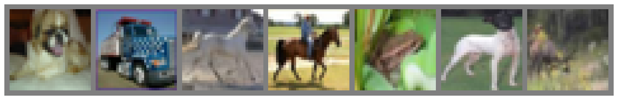

```
            dog                       truck                     horse                     horse                     frog                      dog                       deer
```

A continuación creamos nuestro modelo para clasificar imágenes.

En este caso, nuestro modelo tendrá 2 capas convolucionales y 3 capas densas

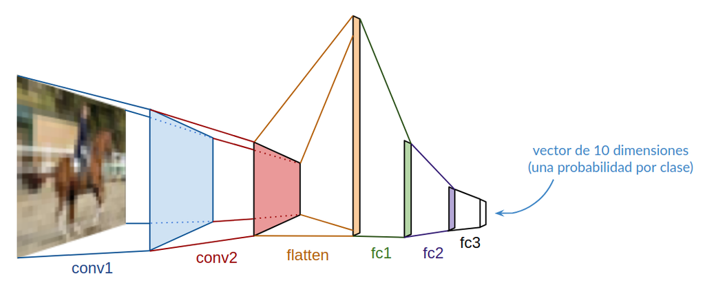

Aquí crearemos una función para mostrar la matriz de confusión

Aqui se implementa el loop de entrenamiento y evaluacion en el set de validación

Ahora entrenaremos nuestro modelo usando Cross-Entropy.

Recordemos la fórmula de la Cross-Entropy:

$$-\sum_{x_i,y_i \in T}{y_i * \log{q(x_i)}} = -\sum_{x_i,y_i \in T}{y_i * \log{\hat{y}_i}}$$

Suponiendo que el modelo retorna un vector $[q_1$ .. $q_{10}]^T$, para un ejemplo de clase 3 nos quedará un término de este estilo (existira uno así para cada ejemplo de entrenamiento):

$$ \begin{pmatrix} 0 \\ 0 \\ 1 \\ 0 \\ 0 \\ 0 \\ 0 \\ 0 \\ 0 \\ 0 \end{pmatrix}^T \begin{pmatrix} \log{q_1} \\ \log{q_2} \\ \log{q_3} \\ \log{q_4} \\ \log{q_5} \\ \log{q_6} \\ \log{q_7} \\ \log{q_8} \\ \log{q_9} \\ \log{q_{10}} \end{pmatrix} = \log{q_3}$$

Con esto vemos que el único valor que nos importa maximizar es $q_3$, lo cual es ideal porque dejamos libre la distribución de los errores. Todos los otros $q_j$ solo nos importan de manera agregada (pues $\sum_j{q_j} = 1$).

```
Epoch N° 1
TRAIN-Batch 391/391 Loss: 0.0160 Acc: 23.29%
TEST-Batch 79/79 Loss: 0.0139 Acc: 34.89%
```

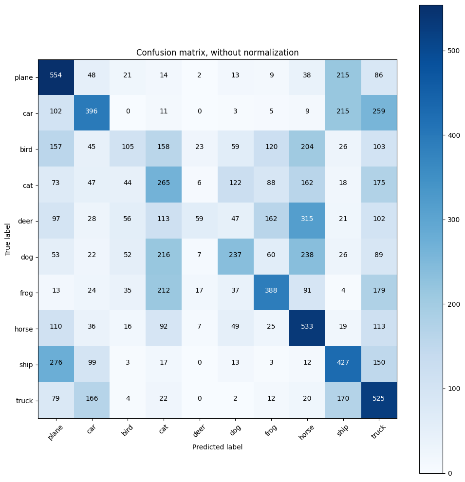

```
Epoch N° 2
TRAIN-Batch 391/391 Loss: 0.0124 Acc: 41.80%
TEST-Batch 79/79 Loss: 0.0116 Acc: 46.34%
```

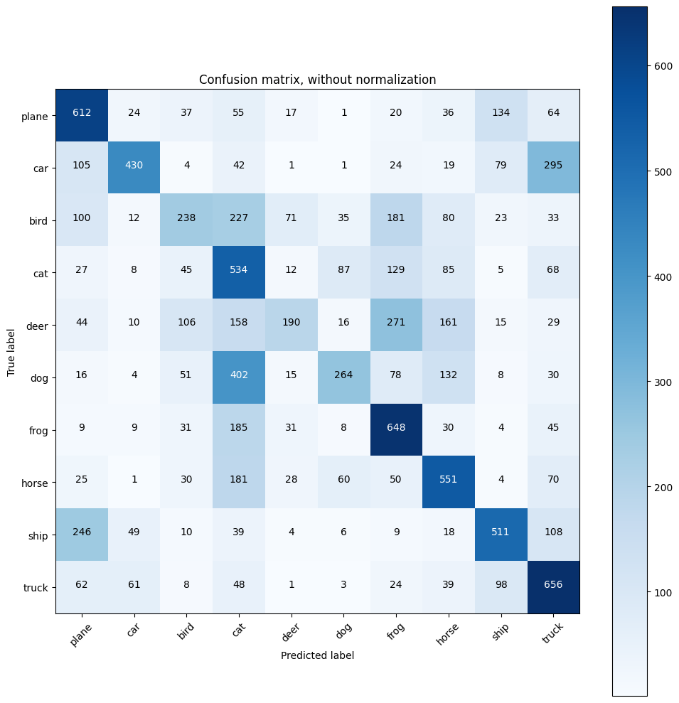

## Entrenamiento de un clasificador con función de pérdida MSE

Ahora estudiemos la MSE. Veremos por qué razón no es buena idea utilizarla en un problema de clasificacion.

Usaremos el mismo modelo anterior, con la única diferencis de que esta vez usaremos una salida de 1 dimensión, que usaremos para identificar la clase (valor de 0 a 9)

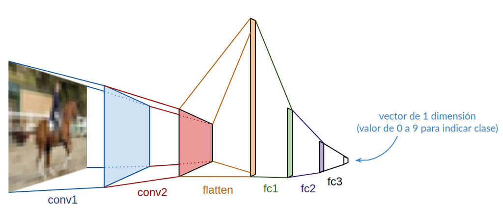

Recordemos la fórmula de la MSE asumiendo que el modelo retorna una predicción como un único valor entre 0 y 9 para indicar la clase:

$$\frac{1}{N} \sum_{x_i,y_i \in T}^N{(\hat{y}_{i} - y_{i})^2}$$

Es fácil ver que si el modelo predijera siempre clase 9, entonces tendría el siguiente MSE (asumiendo clases balanceadas):

$$\frac{(9-0)^2 + (9-1)^2 + (9-2)^2 + (9-3)^2 + (9-4)^2 + (9-5)^2 + (9-6)^2 + (9-7)^2 + (9-8)^2 +(9-9)^2}{10} = $$

```
28.5
```

En cambio, si el modelo predijera siempre clase 5, tendría el siguiente MSE (asumiendo clases balanceadas):

$$\frac{(5-0)^2 + (5-1)^2 + (5-2)^2 + (5-3)^2 + (5-4)^2 + (5-5)^2 + (5-6)^2 + (5-7)^2 + (5-8)^2 +(5-9)^2}{10} = $$

```
8.5
```

Con esto vemos que el modelo no es indiferente al valor numérico que le asigna a las predicciones, pues errores grandes se penalizan más que errores pequeños.

Ahora repetiremos el mismo entrenamiento que hicimos con Cross-Entropy, pero esta vez usando pérdida MSE

```
Epoch N° 1
TRAIN-Batch 391/391 Loss: 0.0630 Acc: 10.59%
TEST-Batch 79/79 Loss: 0.0611 Acc: 10.15%
```

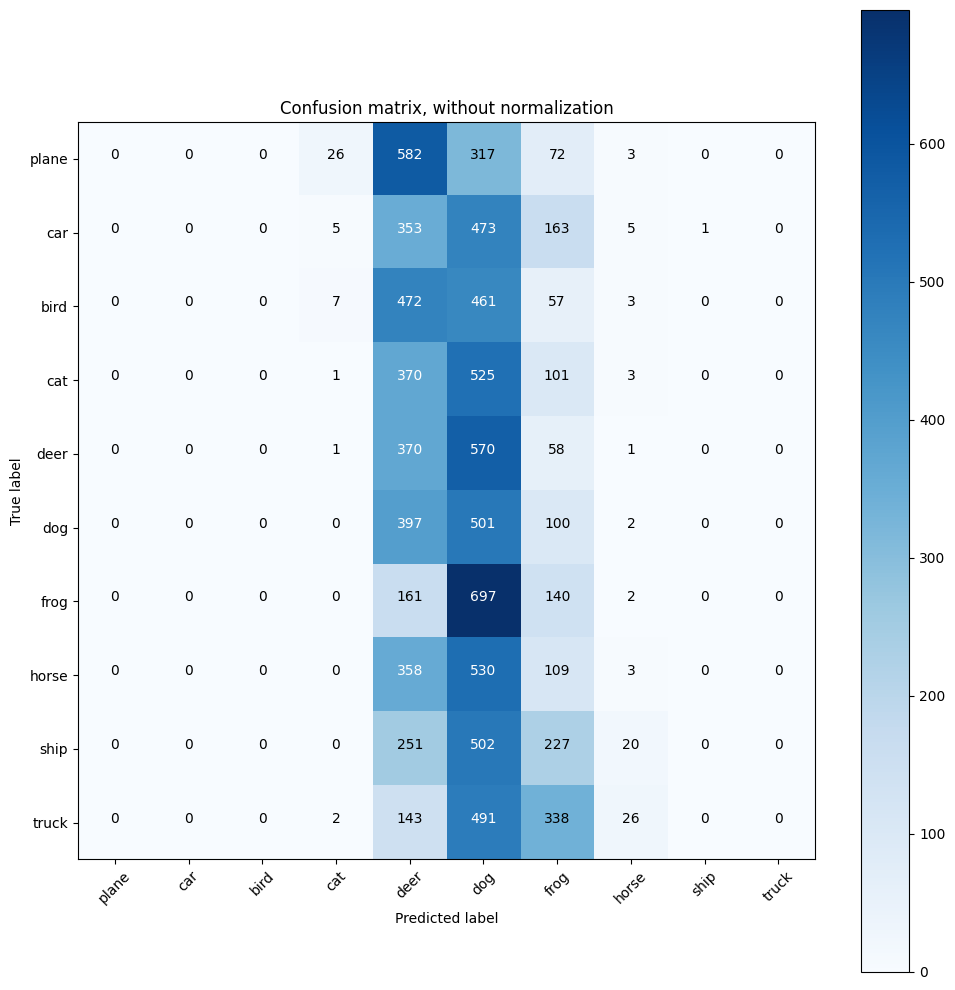

```
Epoch N° 2
TRAIN-Batch 391/391 Loss: 0.0570 Acc: 11.78%
TEST-Batch 79/79 Loss: 0.0550 Acc: 13.20%
```

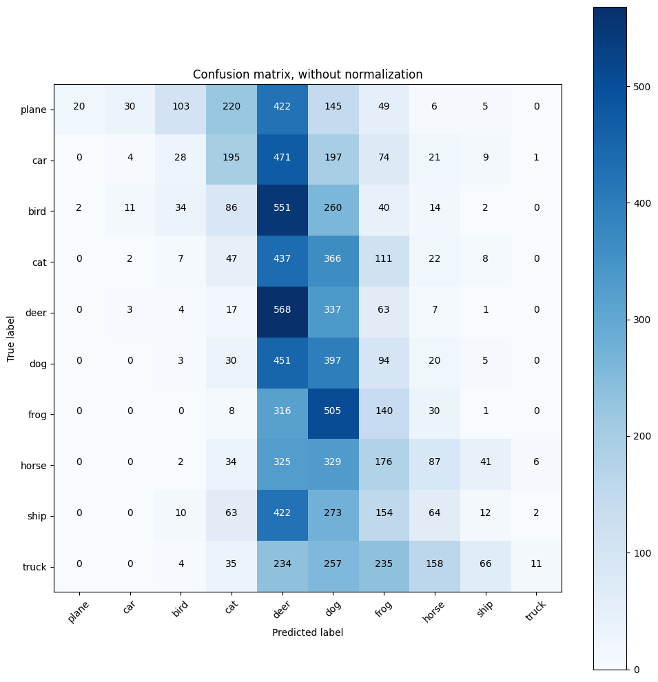

```
Epoch N° 3
TRAIN-Batch 391/391 Loss: 0.0533 Acc: 12.81%
TEST-Batch 79/79 Loss: 0.0517 Acc: 13.75%
```

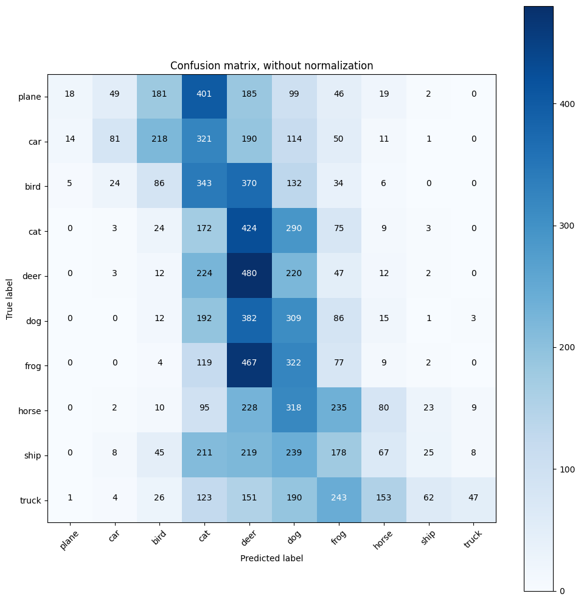

```
Epoch N° 4
TRAIN-Batch 391/391 Loss: 0.0495 Acc: 13.86%
TEST-Batch 79/79 Loss: 0.0496 Acc: 13.59%
```

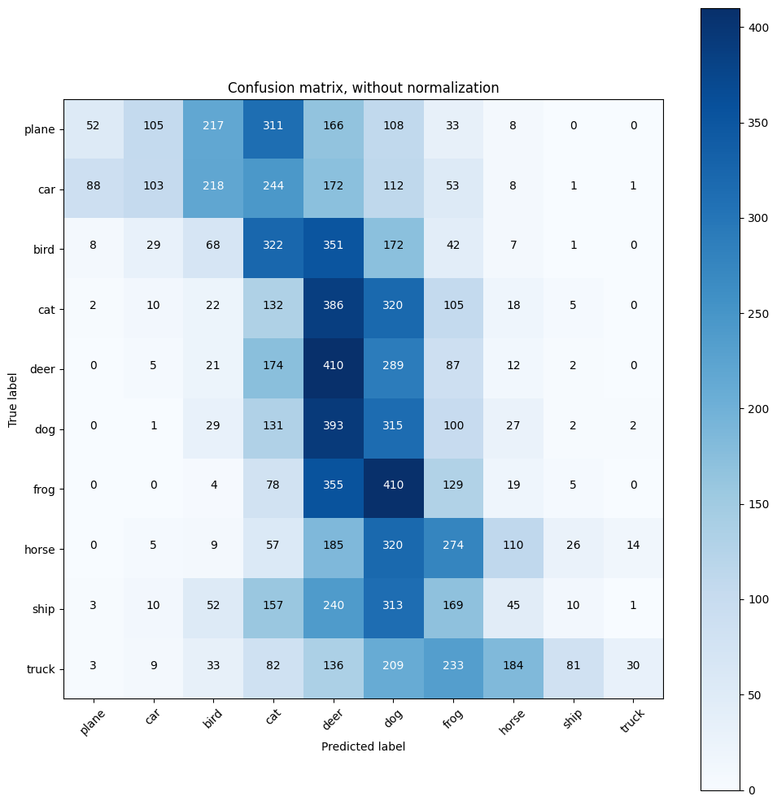

```
Epoch N° 5
TRAIN-Batch 391/391 Loss: 0.0471 Acc: 14.39%
TEST-Batch 79/79 Loss: 0.0468 Acc: 15.04%
```

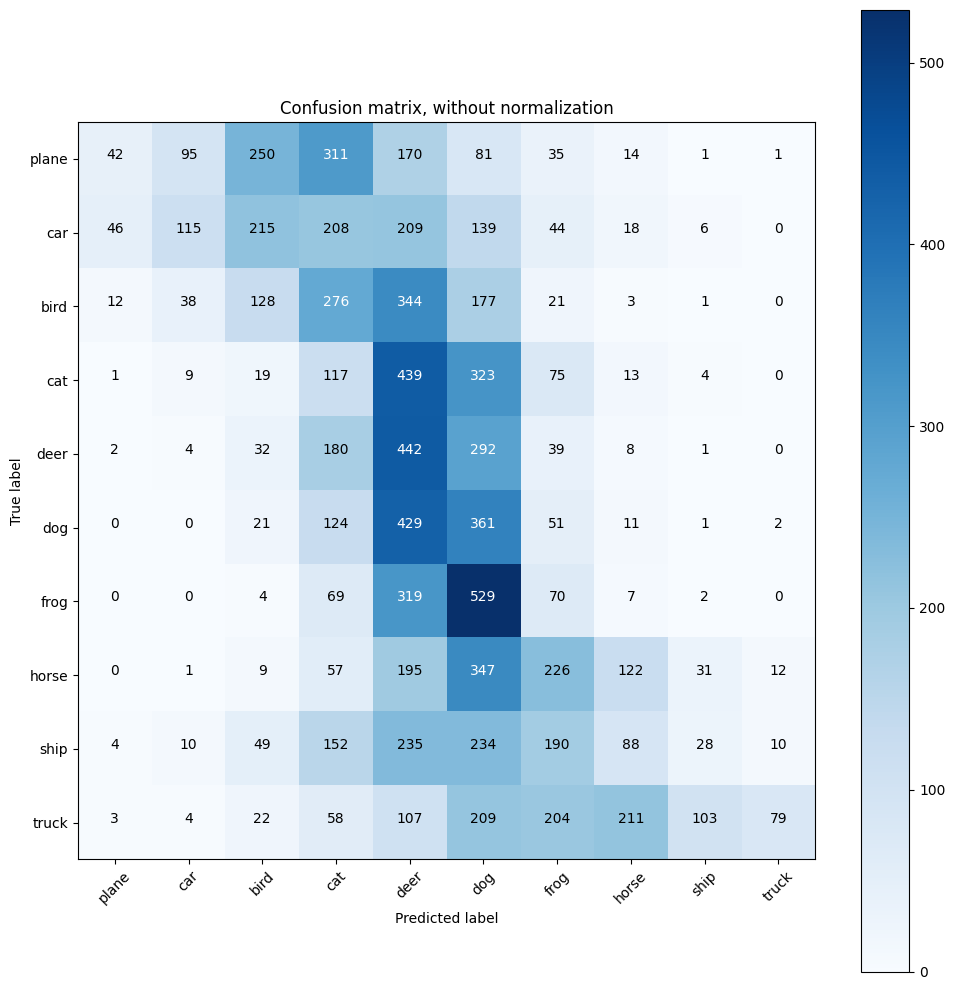

```
Epoch N° 6
TRAIN-Batch 391/391 Loss: 0.0452 Acc: 15.15%
TEST-Batch 79/79 Loss: 0.0478 Acc: 17.58%
```

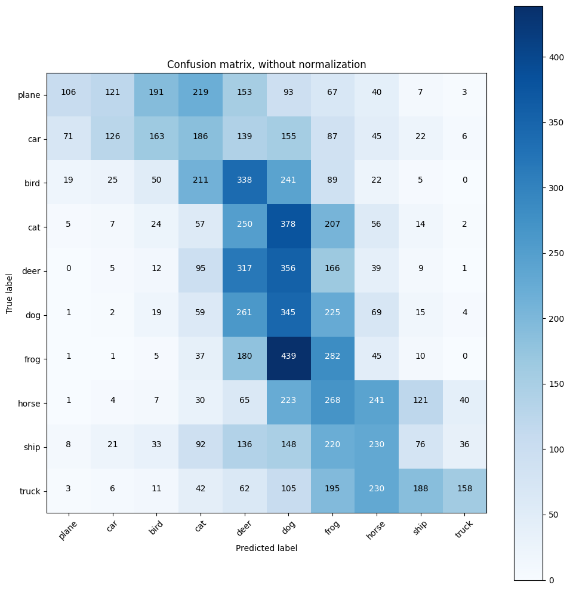

```
Epoch N° 7
TRAIN-Batch 391/391 Loss: 0.0433 Acc: 15.73%
TEST-Batch 79/79 Loss: 0.0447 Acc: 13.24%
```

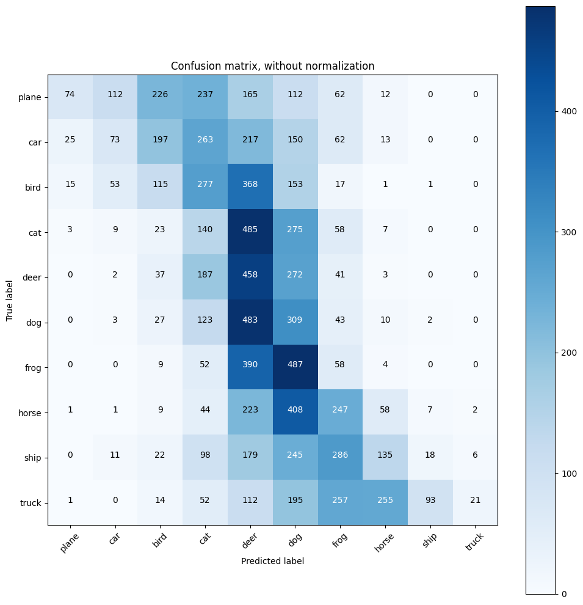

```
Epoch N° 8
TRAIN-Batch 391/391 Loss: 0.0420 Acc: 16.17%
TEST-Batch 79/79 Loss: 0.0462 Acc: 12.64%
```

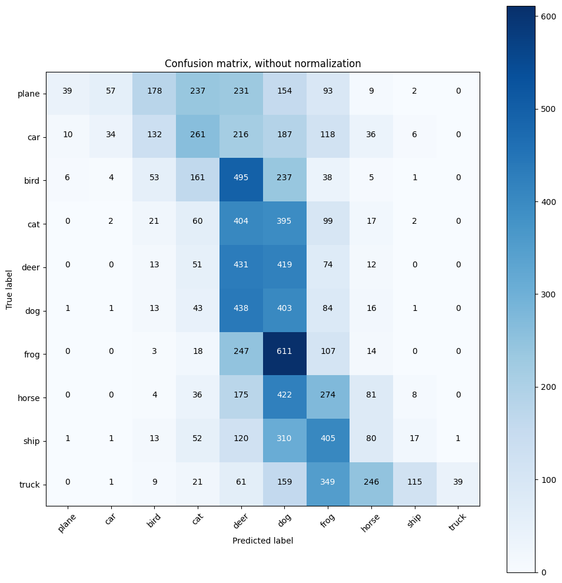

```
Epoch N° 9
TRAIN-Batch 391/391 Loss: 0.0404 Acc: 16.84%
TEST-Batch 79/79 Loss: 0.0461 Acc: 16.14%
```

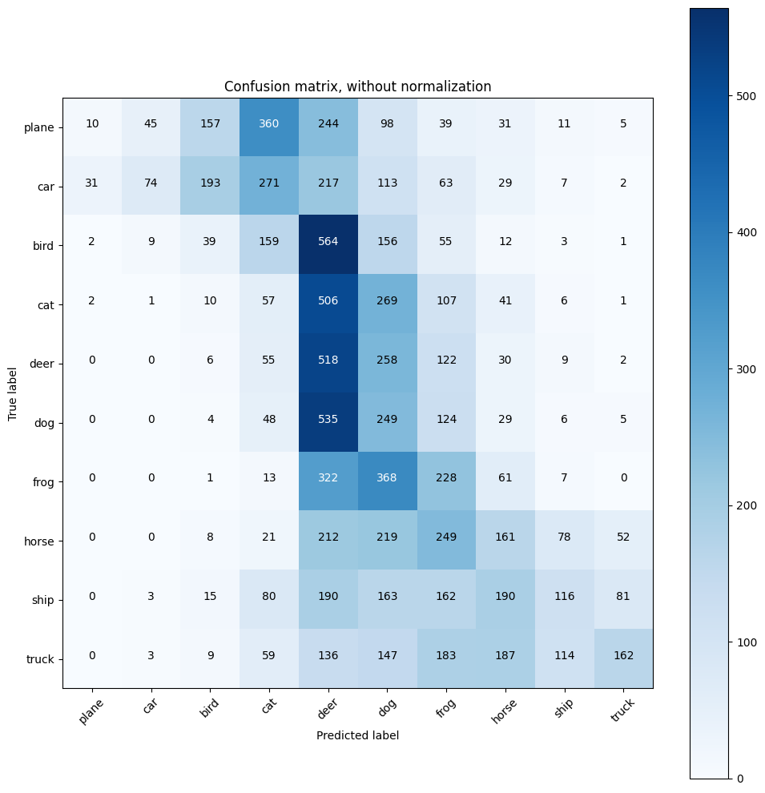

```
Epoch N° 10
TRAIN-Batch 391/391 Loss: 0.0388 Acc: 17.88%
TEST-Batch 79/79 Loss: 0.0440 Acc: 16.51%
```

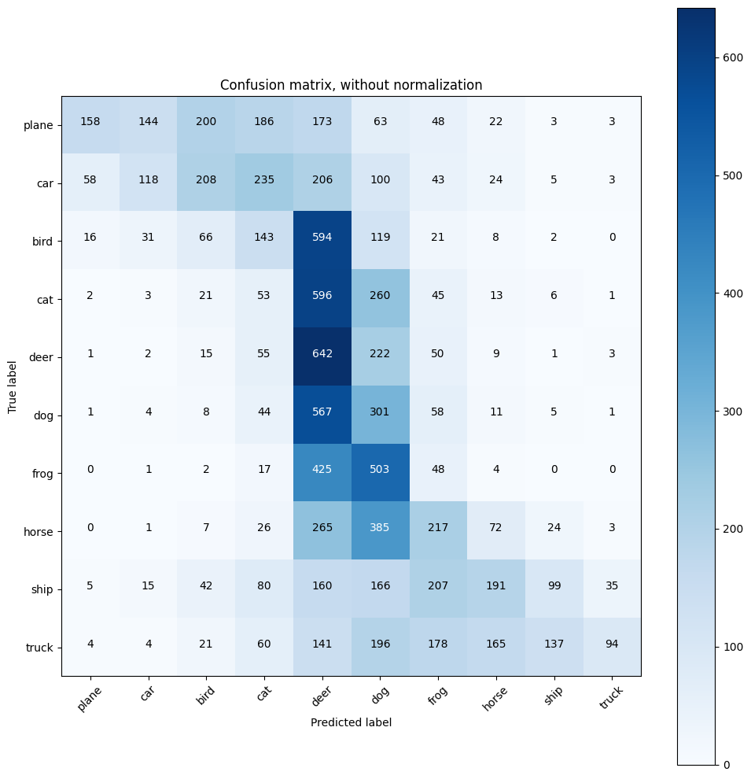

## Actividades

**¿En cuáles de estos problemas usaría MSE en lugar de Cross-Entropy? Marque el check-box de todas las alternativas que correspondan**

- **1) Un sistema que a partir del historial de compras de un cliente, estima la probabilidad de que vaya o no a comprar pasajes en avión dentro de los próximos 30 días**
- **2) Un sistema que permite decidir qué tan positivo o negativo es un comentario en un foro mediante la predicción de un score continuo entre -1 y 1**
- **3) Un sistema que a estima el precio del Dólar a partir del ánalisis de los mensajes de twitter relacionados con Donald Trump**
- **4) Un sistema que a debe aproximar una función discreta que mide la cantidad de alumnos que asistirán a la próxima clase (un número entero entre 1 y 40), a partir del título de la clase y el nombre del profesor**
- **5) Un sistema que a partir de una imagen en blanco y negro predice para cada pixel el color que debería tener si la imagen fuera a color. Para cada pixel predice 3 valores entre 0 y 255: R: Cantidad de Rojo, G: Cantidad de Verde, B: Cantidad de Azul.**
- **6) Un sistema que a debe aproximar una función continua altamente no lineal**

# **Experimento 2: Regularización**

## Entrenamiento de un modelo sin regularización

A continuación analizaremos el efecto de aplicar regularización a la función de pérdida al entrenar una red neuronal para una tarea de clasificación.

El código que aparece a continuación permite la descarga de un archivo que contiene el dataset que utilizaremos en la presente sección. Este archivo contiene un conjunto de vectores bidimensionales, los que pueden pertencer a una de las dos clases definidas: 0 o 1. El archivo consta de 4 columnas separadas por coma, las cuales corresponden a:

- Coordenada x del punto
- Coordenada y del punto
- Identificador de la clase (0 o 1)
- Identificador de si pertenece al conjunto de entrenamiento (1) o test (0)

Luego de descargar el archivo, se imprimirán las primeras y las últimas 5 líneas del archivo para que observe su contenido.

```
X1,X2,CLASS,IS_TRAIN
1.26545132156464321,1.60165432165454654,1.0,1
1.15548213215465465,1.50065424354654655,0.0,1
0.954151554654654656,1.5565465432132132,1.0,1
0.19274023298321466,1.2148826500429524,1.0,1
----------------------------------------
0.3820630273442456,0.18221550123847266,0.0,0
0.6395411833954642,0.4888404606894027,0.0,0
0.783774106927168,-0.9274040390246754,0.0,0
-0.06922387632365572,-0.5067879276205028,0.0,0
0.95548432111321842,1.6645321644654654,0.0,0
```

El siguiente código define una función que permitirá leer los datos desde el archivo descargado, y una función para poder graficar los datos asignando colores a cada vector según su clase. Posteriormente se hace un llamado a cada una de ellas para visualizar como se distribuyen las clases.

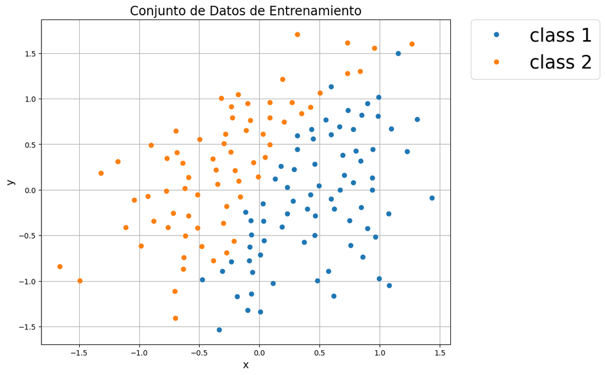

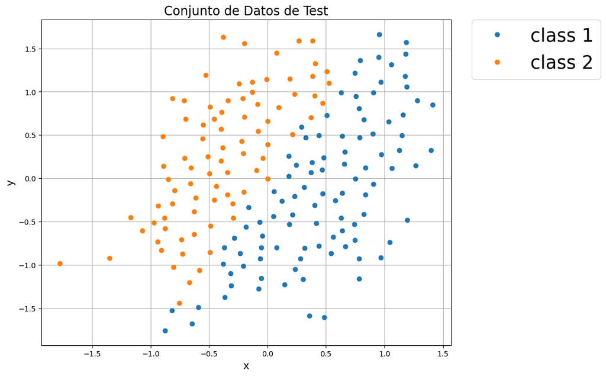

A continuación se definen las clases necesarias para definir un *Dataloader*, el cual es un objeto que permitirá iterar cómodamente sobre los datos dentro del loop de entrenamiento.

La siguiente clase, que llamaremos ClassificationModel, implementa una red neuronal de 3 capas utilizando el framework *PyTorch*. Esta recibe como entreda un valor de dos dimensiones (x, y) y su estructura interna ha sido definida como:

- Layer 1: 1000 unidades
- Layer 2: 1000 unidades
- Layer 3 (salida): 2 unidades

La siguiente función implementa el loop de entrenamiento que se encargará de actualizar los parámetros de la red con el fin de ajustar el modelo a los datos de entrenamiento.

A continuación se crean los objetos encargados de:

- Dataloader: encargado de cargar los datos e iterar sobre ellos
- Modelo de clasificación: clase ClassificationModel
- Función de pérdida: Cross Entropy
- Algoritmo de optimización: Adam

Dentro del algoritmo de optimización podrá encontrar el parámetro *weight_decay*. Este permite controlar el nivel de penalización aplicado sobre la función de pérdida a través de una regularización del tipo L2.

```
Epoch 1: train loss 0.685729 acc 0.798611
Epoch 2: train loss 0.427894 acc 0.923611
Epoch 3: train loss 0.296370 acc 0.944444
Epoch 4: train loss 0.221199 acc 0.958333
Epoch 5: train loss 0.175784 acc 0.958333
Epoch 6: train loss 0.146018 acc 0.958333
Epoch 7: train loss 0.125743 acc 0.965278
Epoch 8: train loss 0.111783 acc 0.965278
Epoch 9: train loss 0.101626 acc 0.965278
Epoch 10: train loss 0.094257 acc 0.965278
Epoch 11: train loss 0.089069 acc 0.972222
Epoch 12: train loss 0.085282 acc 0.965278
Epoch 13: train loss 0.082205 acc 0.965278
Epoch 14: train loss 0.079623 acc 0.972222
Epoch 15: train loss 0.077527 acc 0.972222
Epoch 16: train loss 0.075605 acc 0.972222
Epoch 17: train loss 0.073737 acc 0.972222
Epoch 18: train loss 0.071914 acc 0.972222
Epoch 19: train loss 0.070323 acc 0.972222
Epoch 20: train loss 0.068813 acc 0.972222
Epoch 21: train loss 0.067322 acc 0.972222
Epoch 22: train loss 0.065956 acc 0.965278
Epoch 23: train loss 0.064797 acc 0.965278
Epoch 24: train loss 0.063787 acc 0.965278
Epoch 25: train loss 0.062814 acc 0.965278
Epoch 26: train loss 0.061964 acc 0.965278
Epoch 27: train loss 0.061151 acc 0.965278
Epoch 28: train loss 0.060318 acc 0.965278
Epoch 29: train loss 0.059602 acc 0.979167
Epoch 30: train loss 0.058918 acc 0.979167
Epoch 31: train loss 0.058215 acc 0.979167
Epoch 32: train loss 0.057550 acc 0.979167
Epoch 33: train loss 0.056864 acc 0.972222
Epoch 34: train loss 0.056119 acc 0.979167
Epoch 35: train loss 0.055379 acc 0.979167
Epoch 36: train loss 0.054639 acc 0.979167
Epoch 37: train loss 0.053860 acc 0.979167
Epoch 38: train loss 0.053068 acc 0.979167
Epoch 39: train loss 0.052255 acc 0.979167
Epoch 40: train loss 0.051472 acc 0.979167
```

[output cut: 95 more lines]

```
Epoch 136: train loss 0.015569 acc 1.000000
Epoch 137: train loss 0.015459 acc 1.000000
Epoch 138: train loss 0.015365 acc 1.000000
Epoch 139: train loss 0.015269 acc 1.000000
Epoch 140: train loss 0.015179 acc 1.000000
Epoch 141: train loss 0.015088 acc 1.000000
Epoch 142: train loss 0.015000 acc 1.000000
Epoch 143: train loss 0.014911 acc 1.000000
Epoch 144: train loss 0.014822 acc 1.000000
Epoch 145: train loss 0.014736 acc 1.000000
Epoch 146: train loss 0.014652 acc 1.000000
Epoch 147: train loss 0.014567 acc 1.000000
Epoch 148: train loss 0.014479 acc 1.000000
Epoch 149: train loss 0.014404 acc 1.000000
Epoch 150: train loss 0.014327 acc 1.000000
```

A continuación revisaremos cómo le fue al modelo en el set de test

```
Test loss 0.212995 acc 0.955801
```

La siguiente función permite crear un gráfico con el límite de clasificación aprendido por el modelo, y los datos de entrenamiento entregados durante entrenamiento.

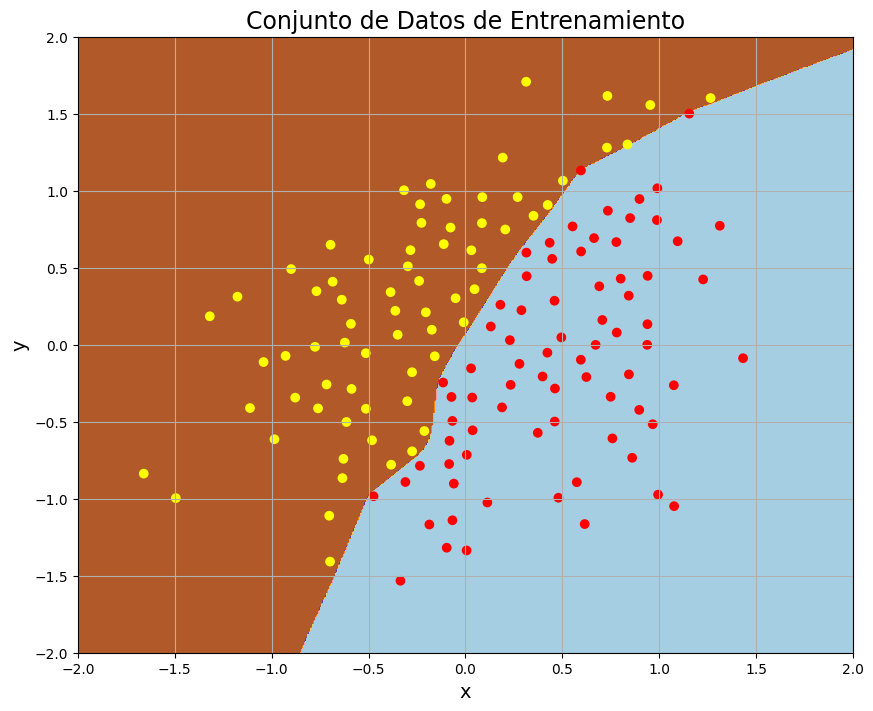

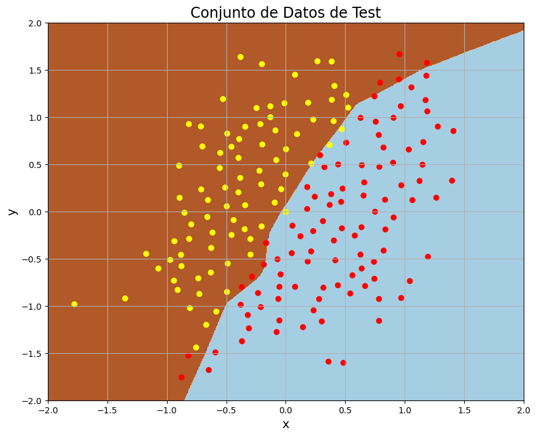

## ¿Qué pasa si agregamos regularización L2?

```
Epoch 1: train loss 0.688394 acc 0.548611
Epoch 2: train loss 0.688837 acc 0.548611
Epoch 3: train loss 0.689136 acc 0.548611
Epoch 4: train loss 0.689295 acc 0.555556
Epoch 5: train loss 0.689376 acc 0.562500
Epoch 6: train loss 0.689468 acc 0.562500
Epoch 7: train loss 0.689594 acc 0.569444
Epoch 8: train loss 0.689767 acc 0.569444
Epoch 9: train loss 0.690003 acc 0.569444
Epoch 10: train loss 0.690280 acc 0.548611
Epoch 11: train loss 0.690602 acc 0.555556
Epoch 12: train loss 0.690957 acc 0.534722
Epoch 13: train loss 0.691307 acc 0.548611
Epoch 14: train loss 0.691673 acc 0.555556
Epoch 15: train loss 0.692031 acc 0.541667
Epoch 16: train loss 0.692363 acc 0.527778
Epoch 17: train loss 0.692650 acc 0.520833
Epoch 18: train loss 0.692865 acc 0.520833
Epoch 19: train loss 0.693005 acc 0.520833
Epoch 20: train loss 0.693078 acc 0.520833
Epoch 21: train loss 0.693110 acc 0.520833
Epoch 22: train loss 0.693116 acc 0.520833
Epoch 23: train loss 0.693105 acc 0.520833
Epoch 24: train loss 0.693091 acc 0.520833
Epoch 25: train loss 0.693082 acc 0.520833
Epoch 26: train loss 0.693079 acc 0.520833
Epoch 27: train loss 0.693075 acc 0.520833
Epoch 28: train loss 0.693072 acc 0.520833
Epoch 29: train loss 0.693067 acc 0.520833
Epoch 30: train loss 0.693062 acc 0.520833
Epoch 31: train loss 0.693057 acc 0.520833
Epoch 32: train loss 0.693048 acc 0.520833
Epoch 33: train loss 0.693042 acc 0.520833
Epoch 34: train loss 0.693038 acc 0.520833
Epoch 35: train loss 0.693032 acc 0.520833
Epoch 36: train loss 0.693026 acc 0.520833
Epoch 37: train loss 0.693023 acc 0.520833
Epoch 38: train loss 0.693022 acc 0.520833
Epoch 39: train loss 0.693022 acc 0.541667
Epoch 40: train loss 0.693026 acc 0.708333
```

[output cut: 95 more lines]

```
Epoch 136: train loss 0.693147 acc 0.520833
Epoch 137: train loss 0.693147 acc 0.520833
Epoch 138: train loss 0.693147 acc 0.520833
Epoch 139: train loss 0.693147 acc 0.520833
Epoch 140: train loss 0.693147 acc 0.520833
Epoch 141: train loss 0.693147 acc 0.520833
Epoch 142: train loss 0.693147 acc 0.520833
Epoch 143: train loss 0.693147 acc 0.520833
Epoch 144: train loss 0.693147 acc 0.520833
Epoch 145: train loss 0.693147 acc 0.520833
Epoch 146: train loss 0.693147 acc 0.520833
Epoch 147: train loss 0.693147 acc 0.520833
Epoch 148: train loss 0.693147 acc 0.520833
Epoch 149: train loss 0.693147 acc 0.520833
Epoch 150: train loss 0.693147 acc 0.520833
```

```
Test loss 0.693147 acc 0.546961
```

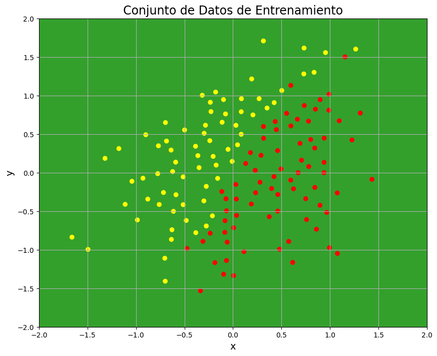

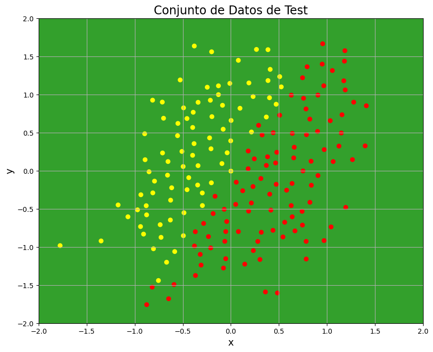

## Actividades

- **1. Explique brevemente ¿Cuál es la principal diferencia entre la forma de los límites de clasificación del modelo sin regularización v/s con regularización?**

- **3. Al comparar el modelo sin regularización v/s el con regularización.**
  - ¿Cuál es mejor en el conjunto de entrenamiento?
  - ¿Cuánto accuracy obtuvo en el conjunto de entrenamiento?
- **4. Al comparar el modelo sin regularización v/s el con regularización.**
  - **¿Cuál es mejor en el conjunto de test?**
  - **¿Cuánto accuracy obtuvo en el conjunto de test?**
- **5. Unicamente considerando lo analizado en las preguntas 3 y 4. ¿Qué estrategia recomendaría usar para generar el modelo definitivo?**
- **6. Revisando el código anterior, ¿qué línea tendría que editar si usted quisiera aumentar a 0.9 la importancia de la regularización L2? Copie y pegue la línea de código modificada aquí**
- **7. Ejecute el código con esta regularización L2 ponderada por 0.9. ¿Qué efecto tiene en la curva que separa las clases?**
- **8. Repita la actividad 7, pero esta vez con regularización L2 ponderada por 100000.**
  - **¿Qué efecto tiene en el accuracy de test?**
  - **¿Qué efecto tiene en el gráfico que separa las clases?**
  - **¿Qué explica este fenómeno?**

*Hint: Puede servirle de ayuda intentar explicarlo en base a la fórmula de la función de pérdida que recibe el modelo*

# **Experimento 3: Tareas Auxiliares**

En este experimento usaremos un dataset llamado **celebA**, que consta de imágenes RGB de caras de celebridades.

Este dataset cuenta con **40 anotaciones diferentes** (clase binaria) para cada una de las imágenes, además de una anotación en coordenadas (x,y) para 5 keypoints:

- **Landmarks**: posición (x,y) de 5 puntos clave (ojos, nariz y extremos de la boca)
- **Attractive**: Un valor binario que indica si el anotador consideraba que la persona era atractiva o no
- **Mustache**: Un valor binario que indica si la persona tiene bigote o no
- **Straight_Hair**: Un valor binario que indica si la persona tiene pelo liso o no
- etc

Aqui dejamos un listado de todas las posibles tareas principales y todas las posibles tareas auxiliares. Esto nos ayudará a probar diferentes escenarios y observar cómo se comporta el modelo al combinar las tareas.

Para hacer la tarea más difícil y para acelerar los experimentos, se pre-filtró las imágenes para quedarnos con 10.000 en cada set (entrenamiento, validación y test), y se transformaron a tamaño 40x40 pixeles.

A continuación descargamos y descomprimimos el dataset

Y luego visualizaremos dos imágenes del dataset, junto con su imagen transformada y con los Landmarks graficados.

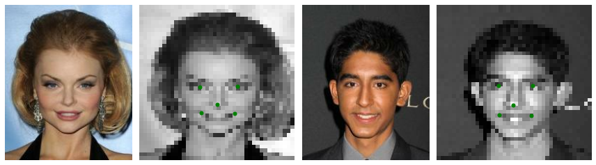

Aquí implementamos el dataloader y las funcionalidades para manejar los datos de entrada

Y luego creamos nuestro modelo. Intencionalmente usamos una arquitectura casi idéntica a la del Experimento 1. La principal diferencia es que incorporamos opcionalmente una predicción auxiliar que puede ser binaria o de 10 dimensiones, según la tarea.

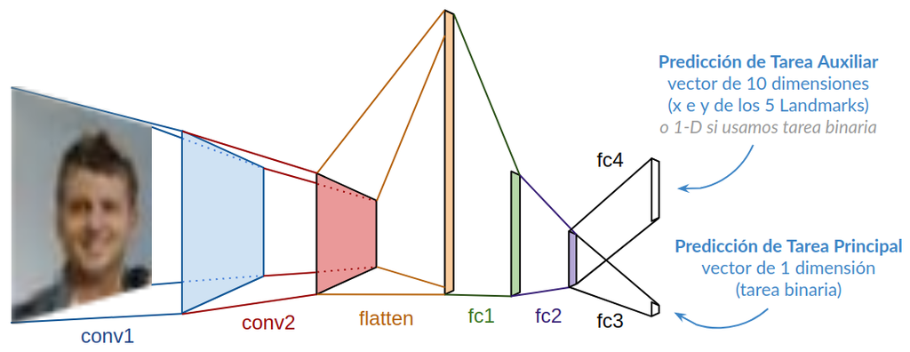

En la siguiente celda implementamos funcionalidades para calcular métricas y el loop de entrenamiento / test

En esta clase implementaremos nuestra función de pérdida, que permite opcionalmente incorporar una pérdida correspondiente a la tarea auxiliar.

En caso de que la tarea auxiliar sea binaria, utilizaremos Cross-Entropy (binaria), pero si es la tarea de 'Landmarks', usaremos MSE, pues queremos que el modelo maneje la predicción de las coordenadas (x,y) como un problema de regresión.

La tarea principal, por simplicidad, asumiremos que siempre es binaria (y por lo tanto usaremos Cross-Entropy.

Recordemos lo que vimos en clases sobre cómo combinar ambas pérdidas:

$$ \mathit{Loss} = \mathit{Loss}_{principal} + \lambda \mathit{Loss}_{auxiliar} $$

A continuación está el código para lanzar el entrenamiento. En este primer ejemplo, usaremos como tarea principal el atributo 'Smiling' sin tarea auxiliar.

```
TRAINING EPOCH 1 of 10
```

```
   Dev set statistics
     loss:        0.336296898937225
     accuracy:    0.852500000000000
     Best Accuracy:   0.85250

TRAINING EPOCH 2 of 10
   Dev set statistics
     loss:        0.298116353774071
     accuracy:    0.873600000000000
     Best Accuracy:   0.87360

TRAINING EPOCH 3 of 10
   Dev set statistics
     loss:        0.280555073976517
     accuracy:    0.881800000000000
     Best Accuracy:   0.88180

TRAINING EPOCH 4 of 10
   Dev set statistics
     loss:        0.298502654099464
     accuracy:    0.872400000000000
     Best Accuracy:   0.88180

TRAINING EPOCH 5 of 10
   Dev set statistics
     loss:        0.271049367570877
     accuracy:    0.887400000000000
     Best Accuracy:   0.88740

TRAINING EPOCH 6 of 10
   Dev set statistics
     loss:        0.301339973545074
     accuracy:    0.871800000000000
     Best Accuracy:   0.88740

TRAINING EPOCH 7 of 10
   Dev set statistics
     loss:        0.287844033110142
     accuracy:    0.876400000000000
     Best Accuracy:   0.88740

TRAINING EPOCH 8 of 10
   Dev set statistics
     loss:        0.267255775928497
     accuracy:    0.888100000000000
     Best Accuracy:   0.88810

TRAINING EPOCH 9 of 10
   Dev set statistics
     loss:        0.267028114438057
     accuracy:    0.890300000000000
     Best Accuracy:   0.89030

TRAINING EPOCH 10 of 10
   Dev set statistics
     loss:        0.281968753278255
     accuracy:    0.885800000000000
     Best Accuracy:   0.89030
```

Ahora probaremos el mismo modelo, pero usando una tarea auxiliar binaria ("Young")

```
TRAINING EPOCH 1 of 10
```

```
   Dev set statistics
     loss:        0.462045311316848
     accuracy:    0.843100000000000
     Best Accuracy:   0.84310

TRAINING EPOCH 2 of 10
   Dev set statistics
     loss:        0.421875298023224
     accuracy:    0.860300000000000
     Best Accuracy:   0.86030

TRAINING EPOCH 3 of 10
   Dev set statistics
     loss:        0.389834236308932
     accuracy:    0.878900000000000
     Best Accuracy:   0.87890

TRAINING EPOCH 4 of 10
   Dev set statistics
     loss:        0.376591418311000
     accuracy:    0.883900000000000
     Best Accuracy:   0.88390

TRAINING EPOCH 5 of 10
   Dev set statistics
     loss:        0.368703131258488
     accuracy:    0.885400000000000
     Best Accuracy:   0.88540

TRAINING EPOCH 6 of 10
   Dev set statistics
     loss:        0.354085481256247
     accuracy:    0.889800000000000
     Best Accuracy:   0.88980

TRAINING EPOCH 7 of 10
   Dev set statistics
     loss:        0.427104263573885
     accuracy:    0.860700000000000
     Best Accuracy:   0.88980

TRAINING EPOCH 8 of 10
   Dev set statistics
     loss:        0.355128167726100
     accuracy:    0.897500000000000
     Best Accuracy:   0.89750

TRAINING EPOCH 9 of 10
   Dev set statistics
     loss:        0.368853715121746
     accuracy:    0.884500000000000
     Best Accuracy:   0.89750

TRAINING EPOCH 10 of 10
   Dev set statistics
     loss:        0.369059672124684
     accuracy:    0.889400000000000
     Best Accuracy:   0.89750
```

Finalmente probaremos una tarea principal de clasificación binaria ("Young") con una tarea auxiliar de regresión ("Landmarks"), para ver que pueden ser combinadas aunque sean de tipo diferente.

```
TRAINING EPOCH 1 of 20
```

```
   Dev set statistics
     loss:        0.560663655757904
     accuracy:    0.741600000000000
     Best Accuracy:   0.74160

TRAINING EPOCH 2 of 20
   Dev set statistics
     loss:        0.503767405700684
     accuracy:    0.772100000000000
     Best Accuracy:   0.77210

TRAINING EPOCH 3 of 20
   Dev set statistics
     loss:        0.475741020536423
     accuracy:    0.790200000000000
     Best Accuracy:   0.79020

TRAINING EPOCH 4 of 20
   Dev set statistics
     loss:        0.468571971988678
     accuracy:    0.791100000000000
     Best Accuracy:   0.79110

TRAINING EPOCH 5 of 20
   Dev set statistics
     loss:        0.457168386650085
     accuracy:    0.795300000000000
     Best Accuracy:   0.79530

TRAINING EPOCH 6 of 20
   Dev set statistics
     loss:        0.457140071964264
     accuracy:    0.800200000000000
     Best Accuracy:   0.80020

TRAINING EPOCH 7 of 20
   Dev set statistics
     loss:        0.448555712890625
     accuracy:    0.800500000000000
     Best Accuracy:   0.80050
```

[output cut: 63 more lines]

```
     loss:        0.473989945697784
     accuracy:    0.805300000000000
     Best Accuracy:   0.81040

TRAINING EPOCH 19 of 20
   Dev set statistics
     loss:        0.497985662555695
     accuracy:    0.805400000000000
     Best Accuracy:   0.81040

TRAINING EPOCH 20 of 20
   Dev set statistics
     loss:        0.456109981727600
     accuracy:    0.801900000000000
     Best Accuracy:   0.81040
```

## Actividades

- **1. Supongamos que usted quiere combinar una tarea principal con una tarea auxiliar, pero por la naturaleza de las tareas y funciones de pérdida, la loss asociada a la tarea auxiliar es, por lo general, 1000 veces mayor que la de la tarea principal (es decir, cuando la loss de la tarea principal vale 100, la de la auxiliar vale 100000). ¿Qué tendría que hacer para que el modelo considere ambas pérdidas de manera equilibrada (50%-50%)?**
- **2. Supongamos ahora que tenemos una tarea principal y 4 tareas auxiliares, todas con ordenes de magnitud similar. ¿Qué tendría que hacer para que el modelo considere la pérdida de la tarea principal en un 50% y la pérdida de todas las demás homogeneamente completando el otro 50%?**